# Session 2 — Checking Assumptions

Independence · what must be normal · plots before tests · normality tests and their traps · equal variances · when assumptions fail · Lab 2

Community Medicine Workshop

## Where we are

- Session 1: the design chooses the **family** of test
- Today: the **assumptions** that decide between a parametric test (t, ANOVA, Pearson) and its rank-based partner
- By the end you can:
  - say **what exactly** has to be normal for each test
  - read a histogram and a **Q-Q plot**
  - use normality tests **without being fooled** by them
  - check equal spread, and know why **Welch** is the safe default
  - choose what to do when an assumption fails, and **report it**

## Three assumptions behind most tests

| Assumption | What it means | How you check it |
| --- | --- | --- |
| **Independence** | one person’s value tells you nothing about another’s | **the design** (no test can check it) |
| **Shape** | the right thing is roughly **normal** | plots first, then tests |
| **Equal spread** | groups have similar variances | compare SDs, Levene; or use **Welch** |

Categorical tests have their own assumption (enough **expected** counts): Session 3.

# Topic 1 — Independence

## Independence comes from the design

- **Broken** when the same person is measured twice (before and after, 0, 3 and 6 months) → use a **paired** or **repeated-measures** test
- **Broken** when people come in clusters (families, villages, wards) → Advanced track, workshop A4
- **Not broken** by people being similar: two women of the same age are still independent observations

A test for independent groups on paired data gives the **wrong** p-value. Session 4 shows how wrong.

# Topic 2 — Normality

## What has to be normal?

| Test | What should be roughly normal |
| --- | --- |
| One-sample t | the values themselves |
| Independent t, one-way ANOVA | the values **within each group** (the residuals) |
| **Paired t** | the **differences** (after − before), **not** each column |
| Repeated-measures ANOVA | the residuals at each time point |
| Pearson correlation | the pairs, and the relationship must be **linear** |

Testing the whole outcome column when the test compares groups or pairs checks the wrong thing.

## Look first: the Q-Q plot

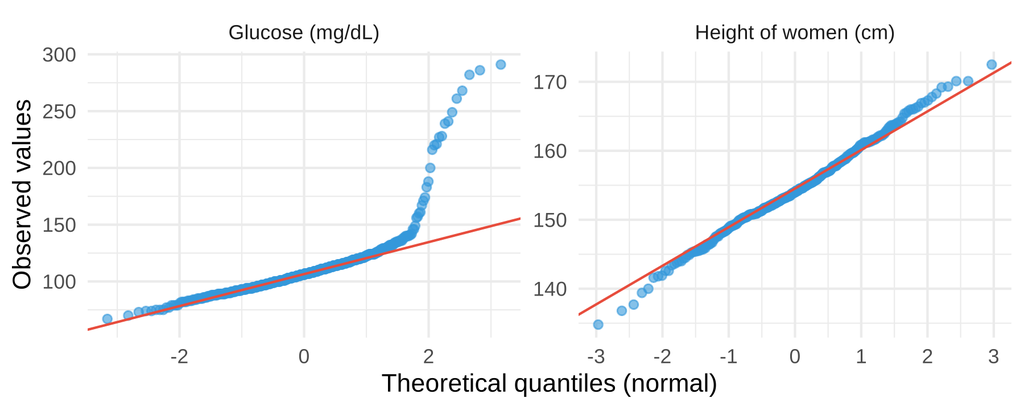

- **Points on the line**: roughly normal (height of women, skewness 0.06)
- **Points curving away at one end**: a long tail (glucose, skewness 3.6)

| Test | Good at | Watch out |
| --- | --- | --- |
| **Shapiro–Wilk** `shapiro.test()` | most powerful all-round; n from 3 to 5,000 | very large n: flags trivial departures |
| **Kolmogorov–Smirnov** `ks.test()` | comparing with a **fully specified** distribution | needs the mean and SD *given in advance*; weak in the tails |
| **Lilliefors** `nortest::lillie.test()` | KS when mean and SD are **estimated** from the data | the version to use instead of plain KS |
| **Anderson–Darling** `nortest::ad.test()` | more sensitive in the **tails** | same large-n problem |

All of them answer one question: “could these data come from a normal distribution?” None says whether the departure **matters** for your test.

## Trap 1: KS against the wrong normal

```r
h_w <- p$height[p$sex_of_participants == "female"]
ks.test(h_w, "pnorm")$p.value                       # compares with mean 0, SD 1!
```

```
[1] 0
```

```r
ks.test(h_w, "pnorm", mean(h_w), sd(h_w))$p.value   # mean and SD from the data
```

```
[1] 0.7193363
```

```r
lillie.test(h_w)$p.value                            # the correct version
```

```
[1] 0.2831439
```

`ks.test(x, "pnorm")` asks whether height looks like a **standard** normal (mean 0, SD 1). It always says no, for any real measurement. With the mean and SD estimated from the data, use **Lilliefors**: women’s height is compatible with normal (p = 0.283).

## Trap 2: the answer depends on n

**All 631 adults**, Shapiro–Wilk:

| variable | skewness | p |
| --- | --- | --- |
| height, women | 0.06 | p = 0.467 |
| height, all | 0.23 | p = 0.003 |
| weight | 0.15 | p = 0.226 |
| age | 0.68 | p < 0.001 |
| glucose | 3.58 | p < 0.001 |

**50 random adults**, age, four draws:

| draw | Shapiro-Wilk |
| --- | --- |
| 1 | p = 0.013 |
| 2 | p = 0.021 |
| 3 | p = 0.017 |
| 4 | p = 0.189 |

- **Height, all**: two normal groups (women and men) mixed together are not normal. What must be normal is the values **within each group**
- Large n: a mild skew in age (0.68) is “significant”, yet a t-test on 631 ages is fine
- Small n: in 1,000 draws of 50 the same ages were “not normal” only 48% of the time, a coin toss. **Never test a random subsample**

## Why mild skew rarely matters

- t-tests and ANOVA compare **means**, and means of large samples are close to normal even when the data are not (**central limit theorem**)
- Rough guide: with **30 or more per group** and no extreme outliers, mild skew (|skewness| < 1) does little harm
- What does matter: **heavy tails and outliers** (glucose up to 291 mg/dL), **small groups**, and **very unequal** group sizes with unequal spread

Decide with the **plot**, the **skewness**, the **sample size** and the **question**. A normality test is one input, not the judge.

# Topic 3 — Equal spread

## Compare the spreads

```r
p |> group_by(sex_of_participants) |> summarise(n = n(), mean = mean(weight), sd = sd(weight))
```

```
# A tibble: 2 × 4
  sex_of_participants     n  mean    sd
  <fct>               <int> <dbl> <dbl>
1 female                335  57.3  9.84
2 male                  296  64.3 12.5
```

```r
leveneTest(weight ~ sex_of_participants, data = p)
```

```
Levene's Test for Homogeneity of Variance (center = median)
       Df F value    Pr(>F)
group   1  13.816 0.0002196 ***
      629
---
Signif. codes:  0 '***' 0.001 '**' 0.01 '*' 0.05 '.' 0.1 ' ' 1
```

- **Levene** (`car::leveneTest`, centred on the median) is robust to non-normal data; **Bartlett** is not
- Rough guide: the larger SD under **twice** the smaller is rarely a problem with similar group sizes
- Here Levene says the spreads differ (p < 0.001), yet the SDs are 12.5 and 9.8 kg: like normality tests, Levene flags small differences in large samples

## Welch is the safe default

- `t.test()` in R runs **Welch’s t-test** unless you add `var.equal = TRUE`
- Similar group sizes: Welch and Student give almost the **same** answer (weight by sex, 95% CI -8.75 to -5.21 vs -8.73 to -5.23 kg)
- Unequal variances, unequal group sizes: Student’s t can be badly wrong; Welch stays correct
- **Testing variances first and then choosing** the test adds its own errors

Use **Welch** for two groups and **Welch ANOVA** (`oneway.test()`) for several. Report Levene only if a reviewer asks.

# Topic 4 — When an assumption fails

| Problem | First | Then |
| --- | --- | --- |
| Impossible values | check the **source**; correct or exclude, and report | sensitivity analysis |
| Skewed, positive data | **log transform**, then a t-test on the log scale (ratio of geometric means) | check the plot again |
| Skew or outliers that stay | **rank-based** test (Mann–Whitney, Wilcoxon, Kruskal–Wallis) | report medians (IQR) |
| Unequal spread | **Welch** t or Welch ANOVA | — |
| Paired or clustered data | a **paired** or **repeated-measures** test | Advanced track (A4) for clusters |

## Write what you did

“Distributions were inspected with histograms and Q-Q plots. Height (within each sex) and weight were approximately normal and are summarised as mean (SD); age and glucose were right-skewed and are summarised as median (IQR). Groups were compared with Welch’s t-test or, for skewed variables, the Mann–Whitney U test.”

- Name the **method of checking**, the **decision**, and the **test used**
- No need to print every normality p-value

## 🔧 Switch to R — Lab 2

**File:** `stats-workshop/labs/lab2_assumptions.R`

- histograms and Q-Q plots for four variables
- Shapiro–Wilk, Lilliefors and Anderson–Darling, and the KS trap
- normality of the **differences** for a paired comparison
- Levene’s test, and Welch vs Student
- a log transform, and when it is not enough

**Time:** 30 minutes · answer the Q questions in the comments

## Self-check quiz (1/5)

For a paired t-test of fasting glucose at presentation and at 6 months, what should be roughly normal?

- Fasting glucose at presentation, tested on its own
- Both glucose columns, each one tested separately on its own
- The pooled glucose values from both visits together
- The 6-month minus presentation differences per person

## Self-check quiz (2/5)

ks.test(p$height, “pnorm”) gives p < 0.001 although height looks normal on a Q-Q plot. Why?

- It compares height with a normal of mean 0 and SD 1
- Height is not normal; the Q-Q plot hides its skew
- The KS test cannot be used for continuous variables
- The sample of 631 is too small for a KS test to work

## Self-check quiz (3/5)

With 631 adults, Shapiro-Wilk gives p < 0.001 for age (skewness 0.7). What follows for a t-test comparing mean age?

- A t-test cannot be used; switch to a rank-based test
- A t-test is reasonable: mild skew and large groups
- Remove the oldest adults until the test is not significant
- Test 50 random adults instead to get a fairer p-value

## Self-check quiz (4/5)

Why is Welch’s t-test a good default for comparing two independent means?

- It does not need the values within each group to be numeric at all
- It stays correct when variances differ and loses little when equal
- It usually gives smaller p-values than Student’s t for the same data
- It removes the need to check the data for impossible measurements

## Self-check quiz (5/5)

Which assumption can only be judged from the study design, not tested on the data?

- That the outcome is roughly normal within each group
- That the groups have roughly equal variances
- That each observation is independent of the others
- That no expected count in the table is below five

## Score and take-home

**Your score:**

- Know **what** must be normal: residuals, **differences**, not the raw column
- **Plot first** (histogram, Q-Q); tests support the plot, and their verdict depends on n
- `ks.test(x, "pnorm")` is a trap: use **Lilliefors**
- **Welch** by default; rank-based tests or a log scale when skew or outliers stay
- Report **how** you checked and **what** you decided

**Next:** Session 3: categorical outcomes